## Tarea 3

Programa Experto en Inteligencia Artificial con Python  
ML3000 - Modelos Analíticos Avanzados  
Estudiante: Natalia Bonilla Villalobos.  
**Curva ROC y Probabilidad de corte**

# Menú

- Ejercicio 1
  - Parte 1
  - Parte 2
  - Parte 3
- Ejercicio 2
  - Parte 1
  - Parte 2
  - Parte 3
- Ejercicio 3
  - Parte 1
  - Parte 2

```python
import warnings
import statistics
import numpy as np
import pandas as pd
import seaborn as sns
import matplotlib.pyplot as plt

from sklearn.model_selection import train_test_split

from sklearn.pipeline import Pipeline
from sklearn.compose import ColumnTransformer
from sklearn.preprocessing import OneHotEncoder, StandardScaler
from sklearn.metrics import confusion_matrix, roc_curve, roc_auc_score

# Clasificacion Bayesiana
from sklearn.naive_bayes import GaussianNB
# Usa Bayes para Análisis Discriminante Lineal - LDA
from sklearn.discriminant_analysis import LinearDiscriminantAnalysis
# Usa Bayes para Análisis Discriminante Cuadrático - QDA
from sklearn.discriminant_analysis import QuadraticDiscriminantAnalysis
# Support Vector Clasification
from sklearn.svm import SVC
# Decision Tree Classifier -> Árboles de Clasificacion
from sklearn.tree import DecisionTreeClassifier
# Random Forest Classifier -> Bosques Aleatorios
from sklearn.ensemble import RandomForestClassifier
# Ada Boost Classifier
from sklearn.ensemble import AdaBoostClassifier
# Gradient Boosting Classifier -> Potenciación para Clasificacion
from sklearn.ensemble import GradientBoostingClassifier
# K Neighbors Classifier -> K Vecinos Clasificacion
from sklearn.neighbors import KNeighborsClassifier
# xgboost -> clasificacion
from xgboost import XGBClassifier
```

# Ejercicio 1

Realice lo siguiente:

- a) Genere modelos utilizando todos los métodos predictivos vistos en el curso y los vistos en cursos anteriores usando el 90% de los datos para la tabla aprendizaje y un 10% para la tabla testing. Utilice los parámetros por defecto o los que usted mejor considere.
- b) Construya un DataFrame que compare todos los modelos generados. Para esto en cada una de las filas debe aparecer el nombre del modelo predictivo y en las columnas deben aparecer los índices Precisión Global, Error Global, Precisión Positiva (PP) y Precisión Negativa (PN). >Cuál de los modelos es mejor según estos índices?
- c) Compare los modelos con respecto a la curva ROC y el área bajo la curva ROC. >Cuál de los modelos es mejor según la curva ROC?.

↑ Volver al Menú

## Parte 1

- a) Genere modelos utilizando todos los métodos predictivos vistos en el curso y los vistos en cursos anteriores usando el 90% de los datos para la tabla aprendizaje y un 10% para la tabla testing. Utilice los parámetros por defecto o los que usted mejor considere.

↑ Volver al Menú

### Exploración de los Datos

#### Carga Datos

```python
# from google.colab import drive
# drive.mount('/content/drive')

# df = pd.read_csv('/content/drive/MyDrive/PROMiDAT_Machine-Learning-wPython/ML3000_Modelos-Analiticos-Avanzados/w3/turnover.csv')
# df.head(5)
```

```python
df = pd.read_csv('turnover.csv')
df.head(5)
```

|  | department | promoted | review | projects | salary | tenure | satisfaction | bonus | avg_hrs_month | left |
| --- | --- | --- | --- | --- | --- | --- | --- | --- | --- | --- |
| 0 | engineering | 0 | 0.467499 | 3 | medium | 4 | 0.829581 | 0 | 178.011622 | no |
| 1 | retail | 0 | 0.640763 | 4 | medium | 6 | 0.626555 | 0 | 182.609830 | no |
| 2 | engineering | 0 | 0.726654 | 4 | medium | 5 | 0.491993 | 0 | 179.829020 | no |
| 3 | engineering | 0 | 0.674880 | 3 | high | 6 | 0.407666 | 0 | 181.973226 | no |
| 4 | operations | 0 | 0.805861 | 4 | medium | 4 | 0.448412 | 1 | 175.680149 | no |

```python
print(f'department: {df['department'].unique().shape}') # Categorica Nominal
print(f'promoted: {df['promoted'].unique()}') # Categorica Nominal. Binaria ---------> pasarla a codigo disyuntivo
print(f'review: {df['review'].unique().shape}') # Numerica Continua
print(f'projects: {df['projects'].unique()}') # Numerica Discreta
print(f'salary: {df['salary'].unique()}') # Categorica Ordinal Ordinal
print(f'tenure: {df['tenure'].unique()}')# Numerica Discreta
print(f'satisfaction: {df['satisfaction'].unique().shape}') # Numerica Continua
print(f'bonus: {df['bonus'].unique()}') # Categorica binaria ------------> pasarla a codigo disyuntivo
print(f'avg_hrs_month: {df['avg_hrs_month'].unique().shape}') # Numerica Continua
print(f'left: {df['left'].unique()}') # target
```

```
department: (10,)
promoted: [0 1]
review: (429,)
projects: [3 4 2 5]
salary: ['medium' 'high' 'low']
tenure: [ 4  6  5  3  8  7  9 10]
satisfaction: (429,)
bonus: [0 1]
avg_hrs_month: (429,)
left: ['no' 'yes']
```

```python
df.info()
```

```
<class 'pandas.core.frame.DataFrame'>
RangeIndex: 429 entries, 0 to 428
Data columns (total 10 columns):
 #   Column         Non-Null Count  Dtype
---  ------         --------------  -----
 0   department     429 non-null    object
 1   promoted       429 non-null    int64
 2   review         429 non-null    float64
 3   projects       429 non-null    int64
 4   salary         429 non-null    object
 5   tenure         429 non-null    int64
 6   satisfaction   429 non-null    float64
 7   bonus          429 non-null    int64
 8   avg_hrs_month  429 non-null    float64
 9   left           429 non-null    object
dtypes: float64(3), int64(4), object(3)
memory usage: 33.6+ KB
```

```python
df.isnull().sum()
```

|  | 0 |
| --- | --- |
| department | 0 |
| promoted | 0 |
| review | 0 |
| projects | 0 |
| salary | 0 |
| tenure | 0 |
| satisfaction | 0 |
| bonus | 0 |
| avg_hrs_month | 0 |
| left | 0 |

**dtype:** int64

#### Transformación de datos

```python
df_cod = df.copy()
df_cod[['promoted_yes','promoted_no']] = pd.get_dummies(df_cod['promoted'], dtype=int) #  1: Sí, 0:No.
df_cod[['bonus_yes','bonus_no']] = pd.get_dummies(df_cod['bonus'], dtype=int) #  1: Sí, 0:No.
df_cod.head(5)
df_cod = df_cod.drop(columns=['promoted', 'bonus'])
df_cod.head(5)
```

|  | department | review | projects | salary | tenure | satisfaction | avg_hrs_month | left | promoted_yes | promoted_no | bonus_yes | bonus_no |
| --- | --- | --- | --- | --- | --- | --- | --- | --- | --- | --- | --- | --- |
| 0 | engineering | 0.467499 | 3 | medium | 4 | 0.829581 | 178.011622 | no | 1 | 0 | 1 | 0 |
| 1 | retail | 0.640763 | 4 | medium | 6 | 0.626555 | 182.609830 | no | 1 | 0 | 1 | 0 |
| 2 | engineering | 0.726654 | 4 | medium | 5 | 0.491993 | 179.829020 | no | 1 | 0 | 1 | 0 |
| 3 | engineering | 0.674880 | 3 | high | 6 | 0.407666 | 181.973226 | no | 1 | 0 | 1 | 0 |
| 4 | operations | 0.805861 | 4 | medium | 4 | 0.448412 | 175.680149 | no | 1 | 0 | 0 | 1 |

```python
df_cod['department'] = df_cod['department'].astype('category')
df_cod['promoted_yes'] = df_cod['promoted_yes'].astype('category')
df_cod['promoted_no'] = df_cod['promoted_no'].astype('category')
df_cod['bonus_yes'] = df_cod['bonus_yes'].astype('category')
df_cod['bonus_no'] = df_cod['bonus_no'].astype('category')
df_cod['salary'] = df_cod['salary'].astype('category')
df_cod.info()
```

```
<class 'pandas.core.frame.DataFrame'>
RangeIndex: 429 entries, 0 to 428
Data columns (total 12 columns):
 #   Column         Non-Null Count  Dtype
---  ------         --------------  -----
 0   department     429 non-null    category
 1   review         429 non-null    float64
 2   projects       429 non-null    int64
 3   salary         429 non-null    category
 4   tenure         429 non-null    int64
 5   satisfaction   429 non-null    float64
 6   avg_hrs_month  429 non-null    float64
 7   left           429 non-null    object
 8   promoted_yes   429 non-null    category
 9   promoted_no    429 non-null    category
 10  bonus_yes      429 non-null    category
 11  bonus_no       429 non-null    category
dtypes: category(6), float64(3), int64(2), object(1)
memory usage: 23.7+ KB
```

#### Distribución de Variable a Predecir

```python
def distribucion_variable_predecir_cat(data:pd.DataFrame, variable_predict:str):
  conteo     = data[variable_predict].value_counts()
  valores    = conteo.to_list()
  categorias = conteo.index.to_list()
  titulo     = "Distribución de la variable %s" % variable_predict

  fig, ax = plt.subplots()
  ax.bar(categorias, valores)

  ax.set_ylabel(variable_predict)
  ax.set_title(titulo)

  for i, valor in enumerate(valores):
    porc = round(valor / sum(valores) * 100, 2)
    text = str(valor) + "\n" + str(porc) + "%"
    ax.text(i, valor * 0.45, text, color='white', ha='center', fontsize=10)

  return(fig)
```

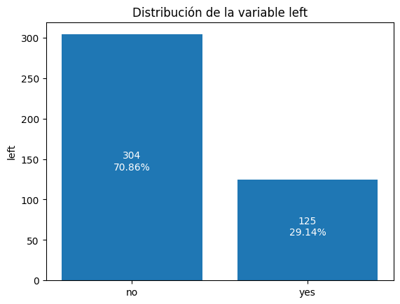

```python
distribucion_variable_predecir_cat(df_cod, 'left')
plt.show()
```

### Poder Predictivo

```python
def poder_predictivo_numerica(data:pd.DataFrame, var:str, variable_predict:str):
  g = sns.FacetGrid(data, hue = variable_predict, height = 4, aspect = 1.8)
  g = g.map(sns.kdeplot, var, fill = True)
  g = g.add_legend()

  g.set_ylabels("Densidad")

  return(g)
```

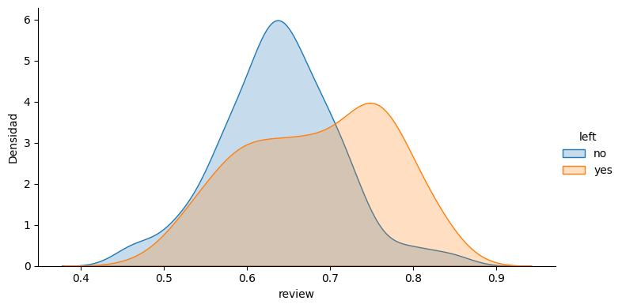

```python
fig = poder_predictivo_numerica(df, 'review', 'left')
plt.show()
```

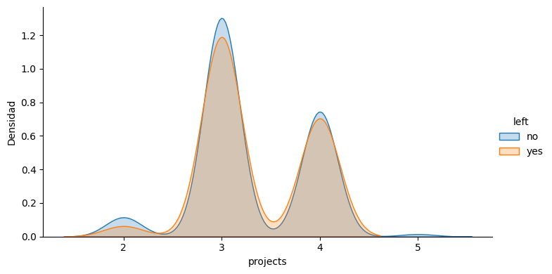

```python
fig = poder_predictivo_numerica(df, 'projects', 'left')
plt.show()
```

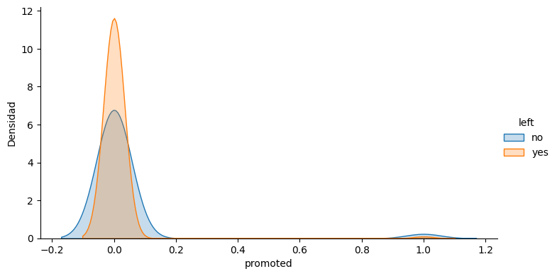

```python
fig = poder_predictivo_numerica(df, 'promoted', 'left')
plt.show()
```

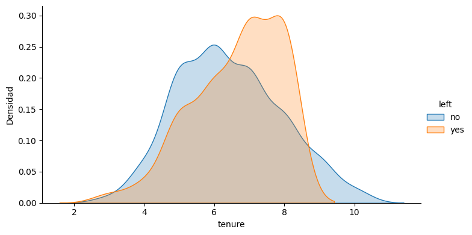

```python
fig = poder_predictivo_numerica(df, 'tenure', 'left')
plt.show()
```

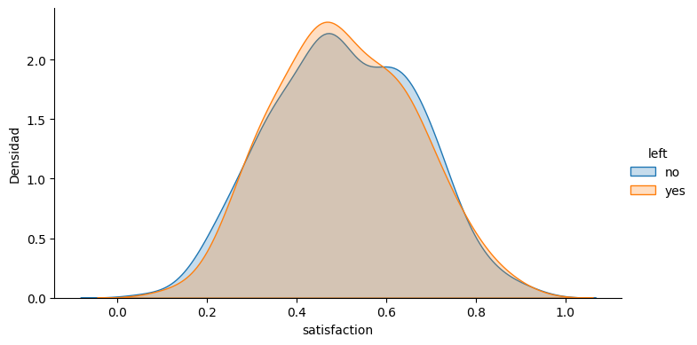

```python
fig = poder_predictivo_numerica(df, 'satisfaction', 'left')
plt.show()
```

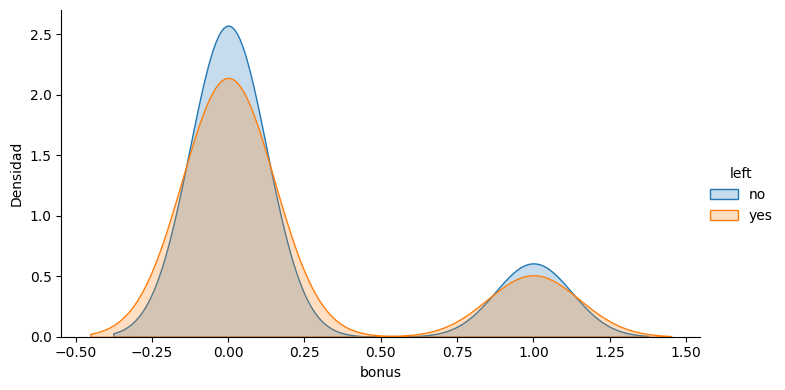

```python
fig = poder_predictivo_numerica(df, 'bonus', 'left')
plt.show()
```

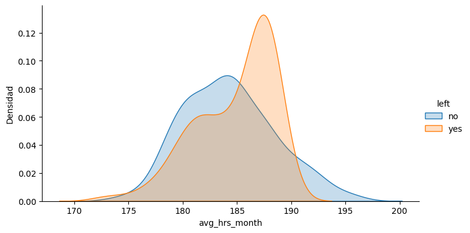

```python
fig = poder_predictivo_numerica(df, 'avg_hrs_month', 'left')
plt.show()
```

### **Clase para la generación de Métodos Predictorios de ML**

```python
# BaseML
# Division X & y
# Division Train-Test
# Division de las Variables Categoricas y Numericas
# Procesar el Modelo, fit()
  # Se necesita el modelo predictorio (la función y sus parametros)

# Clasificacion(BaseML)
# Matriz de confusion
# medición de errrores: precision_global, error_global, precision_positiva, precision_negativa
# Manejo de y como 'categorico'

# Regresion(BaseML)
# calculo para mediciones
# medición de errrores: rsme, mae y er
# Manejo de y como 'numerico' aunque categorico, o sea, hacer transformacion
```

La clase `BaseML` tiene como finalidad entrenar modelos de Machine Learning para este curso.

- De momento solo se implementó para algunos *Modelos Clasificación* en donde la variable target sea catégorica y bi-variable.
- La clase recibe los siguientes parámetros:
  - `df`: Conjuto de datos
  - `target`: Variable a predecir
  - `train_test_split_size`: Division train/test, e.g: 0.90 -> 90% Train.
  - `var_categorical`: recibe una colección con los nombres de las columnas que son de tipo categóricas.  
    Una tupla, e.g: `cat = 'cat_name_col_1', 'cat_name_col_2', 'cat_name_col_3', ...`
  - `var_numerical`: recibe una colección con los nombres de las columnas que son de tipo numéricas.  
    Una tupla, e.g: `num = 'num_name_col_1', 'num_name_col_2', 'num_name_col_3', ...`
  - `labels`: Corresponde a las categorías del que se compone la variable a predecir. (de momento solo puede recibir 2)
  - `machine_learning_model`: El modelo con los parámetros a ser entrenados.
  - `encode_target`: Es un flag para transformar 'y' en int con LabelEncode. Para modelos de Clasificacion que lo requieren.
- Además cuenta con varios métodos que podemos o no accesar, que serían:
  - `prepare_X`: **-> Protegido**: Copia el df, lo separa entre `X` (variables predictoras).
  - `prepare_y`: **-> Protegido**. Se define en las clases.
  - `division_train_test` **-> Protegido**: separa y distribuye el peso de las variables `X_test`, `X_train`, `y_train`, `y_test`, con la división que asigamos en el parámetro `train_test_split_size`.
  - `fit_model` **-> Protegido**: Entrena el modelo, usando los parametros `var_categorical`, `var_numerical` y `machine_learning_model`.
- La clase `Classifier` que hereda de `BaseML` tiene los siguientes métodos que lo diferencia del resto:
  - La medición de errores en métodos de regresión con `precision_global`, `error_global`, `precision_positiva`, `precision_negativa`.
  - `errores` **-> Privado**: se encarga de hacer los cálculos de para las mediciones de los errores de Regresión.
  - `df_error_measure` **-> Público**: obtenemos el nombre de cada modelo de `machine_learning_model` (usando, `type().__name__`), y usa el diccionario `dictionary_of_errors` para retornar un dataframe con el encabezado siguiente: | Modelo | Precision Global ↑ | Error Global ↓| Precision Positiva ↑ | Precision Negativa ↑ | |:------:|:------------------:|:-------------:|:--------------------:|:--------------------:|
- Se pueden acceder a variables internas para corroborar la información e.g: `print(f"X_test:\n{test_base._X_test.head(3)}\n")`
- Esta clase no tiene manejo de errores, y si no se hace una exploración de los datos previa, puede no cumplir su función, o brindar datos erróneos.

Nota de aspectos a mejorar:

- Mejorar la división `X` y `y`
- Manejo de excepciones.
- Para la clase de clasificación, agregar matices con mas de 2 variables, como hemos visto en otras clases.
- Implementar la Class Regressor(BaseML) con la medición de errores en métodos de regresión con `RMSE`, `MAE` y `ER`.

#### **Clase Base para ML**

```python
from abc import ABC, abstractmethod
class BaseML(ABC):
  def __init__(self, df:pd.DataFrame, target, train_test_split_size, var_categorical, var_numerical, labels, machine_learning_model, encode_target=False):
    # print(f"=== BaseML.__init__ iniciando ===")
    self._df = df
    self._target = target
    self._train_test_split_size = train_test_split_size
    self._var_categorical = var_categorical
    self._var_numerical = var_numerical
    self._labels = labels
    self._machine_learning_model = machine_learning_model
    self._encode_target = encode_target  # True/False

    # Atributos
    self._X = None
    self._y = None
    self._X_train = None
    self._X_test = None
    self._y_train = None
    self._y_test = None
    self._model = None
    self._pred = None
    self._df_copy = None

    # llamado a las funciones
    # print(f"Llamando _prepare_X...")
    self._prepare_X()
    # print(f"Llamando _prepare_y...")
    self._prepare_y()
    # print(f"Llamando _division_train_test...")
    self._division_train_test()
    # print(f"Llamando _fit_model...")
    self._fit_model()
    # print(f"=== BaseML.__init__ completado ===")

  def _prepare_X(self):
    self._df_copy = self._df.copy()
    self._X = self._df_copy.drop(columns=[self._target])

  @abstractmethod
  def _prepare_y(self):
      pass

  def _division_train_test(self):
    # if self._y is None:
    #     raise ValueError("self._y es None. _prepare_y() no se ejecutó correctamente.")
    # print(f"Debg: X shape: {self._X.shape}, y shape: {self._y.shape}")
    self._X_train, self._X_test, self._y_train, self._y_test = train_test_split(self._X, self._y, train_size= self._train_test_split_size)

# get
  @property
  def df(self):
      return self._df
  @property
  def X(self):
      return self._X
  @property
  def y(self):
      return self._y
  @property
  def target(self):
      return self._target
  @property
  def train_test_split_size(self):
      return self._train_test_split_size
  @property
  def var_categorical(self):
      return self._var_categorical
  @property
  def var_numerical(self):
      return self._var_numerical
  @property
  def labels(self):
      return self._labels
  @property
  def model(self):
      return self._model
  @property
  def pred(self):
      return self._pred
  @property
  def rmse(self):
      return self._rmse
  @property
  def mae(self):
      return self._mae
  @property
  def er(self):
      return self._er
  @property
  def dictionary_of_errors(self):
      return self._dictionary_of_errors
  @property
  def machine_learning_model(self):
      return self._machine_learning_model


# Methods
  def _fit_model(self):
    preprocesamiento = ColumnTransformer(
      transformers=[
          ('cat', OneHotEncoder(), self._var_categorical),
          ('num', StandardScaler(), self._var_numerical)
    ])

    # clasificador es diferente por modelo
    self._model = Pipeline(steps=[
        ('preprocesador', preprocesamiento),
        ('clasificador', self._machine_learning_model)
    ])

    self._model.fit(self._X_train, self._y_train)
    self._pred = self._model.predict(self._X_test)

# Print
  def __str__(self):
      return (
              f"X: {self._X.head(3)}\n"
              f"y: {self._y[0:6]}\n"
              f"Train size: {self._train_test_split_size}\n"
              f"Categorical Variables: {self._var_categorical}\n"
              f"Numerical Variables: {self._var_numerical}\n"
              f"Train size: {self._train_test_split_size}\n"
              f"Labels: {self._labels}\n"
              f"Se transformo 'y'?: {self._encode_target}\n"
              f"Model: {self._model}\n"
              f"Prediccion: {self._pred[0:6]}\n"
              f"Errores: {self._dictionary_of_errors}\n"
              )
```

#### **Clase con Herencia: Classifier(BaseML)**

```python
class Classifier(BaseML):
  def __init__ (self, df:pd.DataFrame, target, train_test_split_size, var_categorical, var_numerical, labels, machine_learning_model, encode_target=False):
    # print(f">>> Classifier.__init__ iniciando")
    super().__init__(df, target, train_test_split_size, var_categorical, var_numerical, labels, machine_learning_model, encode_target)
    # print(f">>> Classifier.__init__ después de super()")

    self._matrix = None
    self._VN = None
    self._FP = None
    self._FN = None
    self._VP = None
    self._precision_global = None
    self._error_global = None
    self._precision_positiva = None
    self._precision_negativa = None
    self._dictionary_of_errors = None


    #Debg
    # print(f" Llamando __errores...")
    self.__errores()
    # print(f" Classifier.__init__ completo")

  def _prepare_y(self):
    y_series = self._df[self._target]
    #Debg
    # print(f"Preparando 'y'. encode_target={self._encode_target}")
    # print(f"'y' dtype original: {y_series.dtype}")
    # print(f"Valores únicos: {y_series.unique()[:10]}")

    # si eendode == True, llamamos a la funcion que hace la transformacion de y
    # si no, entonces 'y' queda igual con .to_numpy
    if self._encode_target:
      self._encode_y_to_numeric(y_series)
    else:
      self._y = y_series.to_numpy()

    #Debg
    # Warning si es string y no encoded
    # if self._y.dtype == object:
    #   print(f"Warning: 'y' es string (object) y encode_target=False")
    #   print(f"Modelos podrían fallar con 'y' string")

  # Funcion que transforma 'y' en dummie.
  def _encode_y_to_numeric(self, y_series):
    from sklearn.preprocessing import LabelEncoder

    #Debug
    # print("Aplicando LabelEncoder a 'y'")
    self._label_encoder = LabelEncoder()
    self._y = self._label_encoder.fit_transform(y_series)
    # Guarda el mapeo: {'no': 0, 'yes': 1}
    self._classes = self._label_encoder.classes_

    # print(f"'y' convertido a numérico")
    # print(f" Clases originales: {self._classes}")
    # print(f" Mapeo: {dict(zip(self._classes, range(len(self._classes))))}")
    # print(f" Nuevo dtype: {self._y.dtype}")

  # Classifier errors
  def __errores(self):
    self._matrix = confusion_matrix(self._y_test, self._pred, labels= self._labels)
    self._VN = self._matrix[0][0]
    self._FP = self._matrix[0][1]
    self._FN = self._matrix[1][0]
    self._VP = self._matrix[1][1]

    self._precision_global = (self._VN + self._VP) / (self._VN + self._FP + self._FN + self._VP)
    self._error_global = 1 - self._precision_global
    self._precision_positiva = self._VP / (self._FN + self._VP)
    self._precision_negativa = self._VN / (self._VN + self._FP)

    self._dictionary_of_errors = {
      'precision_global': round(self._precision_global*100, 2),
      'error_global': round(self._error_global*100, 2),
      'precision_positiva': round(self._precision_positiva*100, 2),
      'precision_negativa': round(self._precision_negativa*100, 2)
    }

    return self._dictionary_of_errors

  @property
  def confusion_matrix(self):
      return self._matrix

  @property
  def metrics(self):
      return self._dictionary_of_errors

  # Classifier error measuere dic
  def df_error_measure(self):
    df_metricas = pd.DataFrame({
        'Modelo': type(self._machine_learning_model).__name__, #type().__name__ para saber solo el nombre del modelo
        'Precision Global ↑': [self._dictionary_of_errors['precision_global']],
        'Error Global ↓': [self._dictionary_of_errors['error_global']],
        'Precision Positiva ↑': [self._dictionary_of_errors['precision_positiva']], # Fixed: removed '↑' from dictionary key lookup
        'Precision Negativa ↑': [self._dictionary_of_errors['precision_negativa']]  # Fixed: removed '↑' from dictionary key lookup
    })

    return df_metricas
```

```python
# test_classifier = Classifier(df
#                             , target = 'left'
#                             , train_test_split_size= 0.90
#                             , var_categorical = var_categorical
#                             , var_numerical = var_numerical
#                             , labels = ['yes', 'no'],  # 1, 0
#                             , machine_learning_model = LinearDiscriminantAnalysis(solver='lsqr', shrinkage='auto')
#                             )
# print(test_classifier)
# test_classifier.df_error_measure()
```

### Generación de Métodos Predictorios de Clasifición vistos en clase

- Bayes Classifier -> GaussianNB
- LinearDiscriminantAnalysis
- QuadraticDiscriminantAnalysis
- SVC
- KNeighborsClassifier
- DecisionTreeClassifier
- RandomForestClassifier
- AdaBoostClassifier
- GradientBoostingClassifier
- XGBClassifier

```python
# Clasificación de variables entre categóricas y númericas
var_categorical = 'department', 'salary', 'bonus_yes', 'bonus_no', 'promoted_yes', 'promoted_no'
var_numerical = 'review', 'projects', 'tenure', 'satisfaction', 'avg_hrs_month'
```

#### **Bayes Classifier (GaussianNB)**

```python
bayes = Classifier(df_cod,
                  target = 'left',
                  train_test_split_size= 0.90,
                  var_categorical = var_categorical,
                  var_numerical = var_numerical,
                  labels = ['yes', 'no'],  # 1, 0
                  machine_learning_model = GaussianNB()
                  )
bayes_df = bayes.df_error_measure()
bayes_df
```

|  | Modelo | Precision Global ↑ | Error Global ↓ | Precision Positiva ↑ | Precision Negativa ↑ |
| --- | --- | --- | --- | --- | --- |
| 0 | GaussianNB | 41.86 | 58.14 | 10.71 | 100.0 |

#### **LinearDiscriminantAnalysis**

```python
LinearDiscriminant_Analysis = Classifier(df_cod,
                                        target = 'left',
                                        train_test_split_size= 0.90,
                                        var_categorical = var_categorical,
                                        var_numerical = var_numerical,
                                        labels = ['yes', 'no'],  # 1, 0,
                                        machine_learning_model = LinearDiscriminantAnalysis(solver='lsqr', shrinkage='auto')
                                        )
LinearDiscriminant_Analysis_df = LinearDiscriminant_Analysis.df_error_measure()
LinearDiscriminant_Analysis_df
```

|  | Modelo | Precision Global ↑ | Error Global ↓ | Precision Positiva ↑ | Precision Negativa ↑ |
| --- | --- | --- | --- | --- | --- |
| 0 | LinearDiscriminantAnalysis | 55.81 | 44.19 | 92.0 | 5.56 |

#### **QuadraticDiscriminantAnalysis**

```python
QuadraticDiscriminant_Analysis = Classifier(df_cod,
                                            target = 'left',
                                            train_test_split_size= 0.90,
                                            var_categorical = var_categorical,
                                            var_numerical = var_numerical,
                                            labels = ['yes', 'no'],  # 1, 0,
                                            machine_learning_model = QuadraticDiscriminantAnalysis(reg_param = 0.1)
                                            )

QuadraticDiscriminant_Analysis_df = QuadraticDiscriminant_Analysis.df_error_measure()
QuadraticDiscriminant_Analysis_df
```

|  | Modelo | Precision Global ↑ | Error Global ↓ | Precision Positiva ↑ | Precision Negativa ↑ |
| --- | --- | --- | --- | --- | --- |
| 0 | QuadraticDiscriminantAnalysis | 72.09 | 27.91 | 87.5 | 27.27 |

#### **SupportVectorMachine para Clasificación**

```python
svm_classifier = Classifier(df_cod,
                            target = 'left',
                            train_test_split_size= 0.90,
                            var_categorical = var_categorical,
                            var_numerical = var_numerical,
                            labels = ['yes', 'no'],  # 1, 0,
                            machine_learning_model = SVC(kernel='rbf', probability = True)
                           )

svm_classifier_df = svm_classifier.df_error_measure()
svm_classifier_df
```

|  | Modelo | Precision Global ↑ | Error Global ↓ | Precision Positiva ↑ | Precision Negativa ↑ |
| --- | --- | --- | --- | --- | --- |
| 0 | SVC | 93.02 | 6.98 | 93.75 | 90.91 |

#### **KNeighborsClassifier**

```python
KNeighbors_Classifier = Classifier(df_cod,
                                  target = 'left',
                                  train_test_split_size= 0.90,
                                  var_categorical = var_categorical,
                                  var_numerical = var_numerical,
                                  labels = ['yes', 'no'],  # 1, 0,
                                  machine_learning_model = KNeighborsClassifier(n_neighbors=15, metric = "minkowski")
                                  # machine_learning_model = KNeighborsClassifier(n_neighbors=20, weights='uniform', metric = "canberra")
                                  )

KNeighbors_Classifier_df = KNeighbors_Classifier.df_error_measure()
KNeighbors_Classifier_df
```

|  | Modelo | Precision Global ↑ | Error Global ↓ | Precision Positiva ↑ | Precision Negativa ↑ |
| --- | --- | --- | --- | --- | --- |
| 0 | KNeighborsClassifier | 83.72 | 16.28 | 90.0 | 69.23 |

#### **DecisionTreeClassifier**

```python
DecisionTree_Classifier = Classifier(df_cod,
                                    target = 'left',
                                    train_test_split_size= 0.90,
                                    var_categorical = var_categorical,
                                    var_numerical = var_numerical,
                                    labels = ['yes', 'no'],  # 1, 0,
                                    machine_learning_model = DecisionTreeClassifier(criterion='gini', max_depth=10, min_samples_split=10, min_samples_leaf=10)
                                     )

DecisionTree_Classifier_df = DecisionTree_Classifier.df_error_measure()
DecisionTree_Classifier_df
```

|  | Modelo | Precision Global ↑ | Error Global ↓ | Precision Positiva ↑ | Precision Negativa ↑ |
| --- | --- | --- | --- | --- | --- |
| 0 | DecisionTreeClassifier | 83.72 | 16.28 | 87.88 | 70.0 |

#### **RandomForestClassifier**

```python
RandomForest_Classifier = Classifier(df_cod,
                                    target = 'left',
                                    train_test_split_size= 0.90,
                                    var_categorical = var_categorical,
                                    var_numerical = var_numerical,
                                    labels = ['yes', 'no'],  # 1, 0,
                                    machine_learning_model = RandomForestClassifier(n_estimators=30, max_features='sqrt', criterion = "log_loss")#, max_depth=12)
                                     )

RandomForest_Classifier_df = RandomForest_Classifier.df_error_measure()
RandomForest_Classifier_df
```

|  | Modelo | Precision Global ↑ | Error Global ↓ | Precision Positiva ↑ | Precision Negativa ↑ |
| --- | --- | --- | --- | --- | --- |
| 0 | RandomForestClassifier | 93.02 | 6.98 | 94.74 | 80.0 |

#### **AdaBoostClassifier**

```python
AdaBoost_Classifier = Classifier(df_cod,
                                target = 'left',
                                train_test_split_size= 0.90,
                                var_categorical = var_categorical,
                                var_numerical = var_numerical,
                                labels = ['yes', 'no'],  # 1, 0,
                                machine_learning_model = AdaBoostClassifier(n_estimators=50, learning_rate = 0.1, estimator = DecisionTreeClassifier(max_depth=5))
                                )

AdaBoost_Classifier_df = AdaBoost_Classifier.df_error_measure()
AdaBoost_Classifier_df
```

|  | Modelo | Precision Global ↑ | Error Global ↓ | Precision Positiva ↑ | Precision Negativa ↑ |
| --- | --- | --- | --- | --- | --- |
| 0 | AdaBoostClassifier | 79.07 | 20.93 | 75.86 | 85.71 |

#### **XGBClassifier**

```python
XGB_Classifier = Classifier(df_cod,
                            target = 'left',
                            train_test_split_size= 0.90,
                            var_categorical = var_categorical,
                            var_numerical = var_numerical,
                            labels = [1, 0],  # 'yes', 'no'
                            machine_learning_model = XGBClassifier(n_estimators = 100, learning_rate = 0.1, max_depth = 5),
                            encode_target = True
                            )
XGB_Classifier_df = XGB_Classifier.df_error_measure()
XGB_Classifier_df
```

|  | Modelo | Precision Global ↑ | Error Global ↓ | Precision Positiva ↑ | Precision Negativa ↑ |
| --- | --- | --- | --- | --- | --- |
| 0 | XGBClassifier | 81.4 | 18.6 | 84.85 | 70.0 |

#### **GradientBoostingClassifier**

```python
GradientBoosting_Classifier = Classifier(df_cod,
                                        target = 'left',
                                        train_test_split_size= 0.90,
                                        var_categorical = var_categorical,
                                        var_numerical = var_numerical,
                                        labels = ['yes', 'no'],  # 1, 0,
                                        machine_learning_model = GradientBoostingClassifier(n_estimators=28, learning_rate = 0.1, max_features = 'sqrt')#, max_depth = 5)
                                        )

GradientBoosting_Classifier_df = GradientBoosting_Classifier.df_error_measure()
GradientBoosting_Classifier_df
```

|  | Modelo | Precision Global ↑ | Error Global ↓ | Precision Positiva ↑ | Precision Negativa ↑ |
| --- | --- | --- | --- | --- | --- |
| 0 | GradientBoostingClassifier | 86.05 | 13.95 | 96.43 | 66.67 |

```python
# Regressor_GradientBoosting._y[0:13]
# GradientBoosting_Classifier._y[0:13]
```

## Parte 2

- b) Construya un DataFrame que compare todos los modelos generados. Para esto en cada una de las filas debe aparecer el nombre del modelo predictivo y en las columnas deben aparecer los índices Precisión Global, Error Global, Precisión Positiva (PP) y Precisión Negativa (PN).  
  Cuál de los modelos es mejor según estos índices?

↑ Volver al Menú

```python
all_metrics = pd.concat([bayes_df,
                         LinearDiscriminant_Analysis_df,
                         QuadraticDiscriminant_Analysis_df,
                         svm_classifier_df,
                         KNeighbors_Classifier_df,
                         DecisionTree_Classifier_df,
                         RandomForest_Classifier_df,
                         AdaBoost_Classifier_df,
                         XGB_Classifier_df,
                         GradientBoosting_Classifier_df]).reset_index(drop=True)
all_metrics.sort_values(by='Precision Negativa ↑', ascending=False)
```

|  | Modelo | Precision Global ↑ | Error Global ↓ | Precision Positiva ↑ | Precision Negativa ↑ |
| --- | --- | --- | --- | --- | --- |
| 0 | GaussianNB | 41.86 | 58.14 | 10.71 | 100.00 |
| 3 | SVC | 93.02 | 6.98 | 93.75 | 90.91 |
| 7 | AdaBoostClassifier | 79.07 | 20.93 | 75.86 | 85.71 |
| 6 | RandomForestClassifier | 93.02 | 6.98 | 94.74 | 80.00 |
| 8 | XGBClassifier | 81.40 | 18.60 | 84.85 | 70.00 |
| 5 | DecisionTreeClassifier | 83.72 | 16.28 | 87.88 | 70.00 |
| 4 | KNeighborsClassifier | 83.72 | 16.28 | 90.00 | 69.23 |
| 9 | GradientBoostingClassifier | 86.05 | 13.95 | 96.43 | 66.67 |
| 2 | QuadraticDiscriminantAnalysis | 72.09 | 27.91 | 87.50 | 27.27 |
| 1 | LinearDiscriminantAnalysis | 55.81 | 44.19 | 92.00 | 5.56 |

### **Interpretación**

Al comparar los 10 modelos anteriores de clasificación, denotamos que como el "problema a resolver es la fuga de talento" el modelo mas afin para este problema debería de tener un porcentaje alto de Precisión Positiva, sin sacrificar demasiado PN, entonces, el "mejor" según los índices sería:

- `SVC` como la opción balanceada:
  - `Precision Global`: 93.02%
  - `Error Global`: 6.98%
  - `Precision Positiva`: 93.75%
  - `Precision Negativa`: 90.911%

## Parte 3

- c) Compare los modelos con respecto a la curva ROC y el área bajo la curva ROC.  
  Cuál de los modelos es mejor según la curva ROC?.

↑ Volver al Menú

```python
modelos_de_clasificacion = [bayes,
                            LinearDiscriminant_Analysis,
                            QuadraticDiscriminant_Analysis,
                            svm_classifier,
                            KNeighbors_Classifier,
                            DecisionTree_Classifier,
                            RandomForest_Classifier,
                            AdaBoost_Classifier,
                            XGB_Classifier, # warning
                            GradientBoosting_Classifier]
```

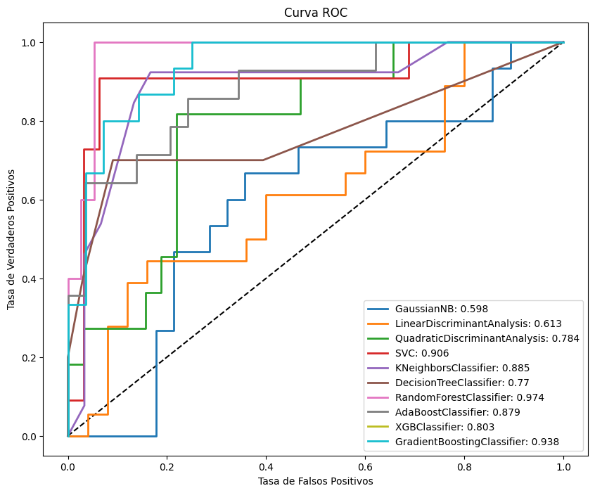

```python
def imprimir_ROC(lista_modelos):
  fig, ax = plt.subplots(figsize = (10, 8))
  no_print = ax.plot([0, 1], [0, 1], color = "black", linestyle = 'dashed')

  for modelo in lista_modelos:
    # guarda el nombre del modelo
    nombre_modelo_ml = type(modelo._machine_learning_model).__name__
    # guarda el modelo.fit
    modelo_ml = modelo.model
    # para mejor lectura, se guardan _X_test y _y_test
    # "extraido" del modelo
    X_test = modelo._X_test
    y_test = modelo._y_test

    # matriz de probabilidades
    scores_modelo_ml = modelo_ml.predict_proba(X_test)
    # valor del area bajo la curva
    area = roc_auc_score(y_test, scores_modelo_ml[:, 1])

    # roc_curve: proporciones de los VP(Sensibilidad) y FP(Especificidad)
    fpr, tpr, umbral = roc_curve(y_test, scores_modelo_ml[:, 1], pos_label = 'yes')
    # imprime los detalles del grafico
    no_print = ax.plot(fpr, tpr, label = f"{nombre_modelo_ml}: " + str(round(area, 3)), lw= 2)
    # no_print = ax.plot(fpr, tpr, label = f"{nombre_modelo_ml}: " + str(round(area*100, 2))+"%", lw= 2)

  no_print = ax.set_xlabel("Tasa de Falsos Positivos")
  no_print = ax.set_ylabel("Tasa de Verdaderos Positivos")
  no_print = ax.set_title("Curva ROC")
  no_print = ax.legend(loc = "lower right")
  plt.show()

imprimir_ROC(modelos_de_clasificacion)
```

**Interpretación**

El mejor modelo segun la curva ROC y AUC es `RandomForestClassifier` con un área bajo la curva de 0.974, indicador que el modelo discrimina bien entre clases. Los modelos `GradientBoostingClassifier` y `SVC` también muestran un buen desempeño.

# Ejercicio 2

[40 puntos] Utilizando nuevamente la tabla `turnover.csv` y los resultados del ejercicio anterior realice lo siguiente:

- a) Seleccione los mejores 3 modelos del ejercicio anterior según la curva ROC.
- b) Determine la mejor probabilidad de corte para los 3 modelos.
- c) Construya un DataFrame que compare todos los 3 modelos generados con la mejor probabilidad de corte. Para esto en cada una de las filas debe aparecer el nombre del modelo predictivo y en las columnas deben aparecer los índices Precisión Global, Error Global, Precisión Positiva (PP) y Precisión Negativa (PN). >Cuál de los modelos es mejor según estos índices?

↑ Volver al Menú

## Parte 1

- a) Seleccione los mejores 3 modelos del ejercicio anterior según la curva ROC.

↑ Volver al Menú

Los mejores modelos de clasificación, según su AUC (área) serían:

- `RandomForestClassifier` -> 97.4%
- `GradientBoostingClassifier` -> 93.8%
- `SupportVectorMachine` -> 90.6%

```python
los_3_mejores_modelos = [RandomForest_Classifier,
                        GradientBoosting_Classifier,
                        svm_classifier
                        ]
```

## Parte 2

- b) Determine la mejor probabilidad de corte para los 3 modelos.

↑ Volver al Menú

```python
def indices_general(MC, nombres = None): #, modelos_de_clasificacion)
    precision_global = np.sum(MC.diagonal()) / np.sum(MC)
    error_global     = 1 - precision_global
    precision_categoria  = pd.DataFrame(MC.diagonal()/np.sum(MC,axis = 1)).T
    if nombres!=None:
        precision_categoria.columns = nombres
    return {"Matriz de Confusión":MC,
            "Precisión Global":   precision_global,
            "Error Global":       error_global,
            "Precisión por categoría":precision_categoria,
            # "Modelo": modelos_de_clasificacion
            }
```

### RandomForest_Classifier

```python
rf_classifier = RandomForest_Classifier.model
# rf_classifier
rf_classifier_X_test = RandomForest_Classifier._X_test
rf_classifier_y_test = RandomForest_Classifier._y_test
rf_classifier_y = RandomForest_Classifier._y
probabilidades = rf_classifier.predict_proba(rf_classifier_X_test)
# probabilidades[0:5, :]
probabilidad_yes = probabilidades[:, 1]
# probabilidad_yes

# Aplicamos una Regla de Decisión
corte = np.arange(0, 1, 0.1)
tabla = []
for c in corte:
    print("====================="*2)
    print("Probabilidad de Corte: ",c)
    print("====================="*2)
    prediccion = np.where(probabilidad_yes > c, "yes", "no") #where hace un arreglo con asignaciones dependiendo de la condición.
    # Calidad de la predicción
    MC = confusion_matrix(rf_classifier_y_test, prediccion)
    indices = indices_general(MC,
                              # type(RandomForest_Classifier._machine_learning_model).__name__,
                              list(np.unique(rf_classifier_y))
                              )
    ##### Tabla #####
    tabla = np.append(tabla,[ c, 1 - indices['Error Global']])
    precision_categoria = MC.diagonal()/np.sum(MC, axis=1)
    tabla = np.append(tabla,precision_categoria)
    ##### #####
    for k in indices:
        print("\n%s:\n%s"%(k,str(indices[k])))
```

```
==========================================
Probabilidad de Corte:  0.0
==========================================

Matriz de Confusión:
[[ 3 35]
 [ 0  5]]

Precisión Global:
0.18604651162790697

Error Global:
0.813953488372093

Precisión por categoría:
         no  yes
0  0.078947  1.0
==========================================
Probabilidad de Corte:  0.1
==========================================

Matriz de Confusión:
[[19 19]
 [ 0  5]]

Precisión Global:
0.5581395348837209

Error Global:
0.4418604651162791

Precisión por categoría:
    no  yes
0  0.5  1.0
==========================================
Probabilidad de Corte:  0.2
==========================================

Matriz de Confusión:
[[30  8]
```

[output cut: 115 more lines]

```
==========================================

Matriz de Confusión:
[[38  0]
 [ 5  0]]

Precisión Global:
0.8837209302325582

Error Global:
0.11627906976744184

Precisión por categoría:
    no  yes
0  1.0  0.0
```

```python
tabla_rf_classifier = np.array(tabla).reshape(10,4)
# print(tabla)
# tabla_rf_classifier
columnas =["Corte", "PG", "PN", "PP"]
# columnas
df_cortes_rf = pd.DataFrame(tabla_rf_classifier, columns = columnas)
# df_cortes_rf
# df_cortes_rf.Corte = ["%.2f" % x for x in df_cortes_rf.Corte] #Se pasa el corte a un string
df_cortes_rf["Modelo"] = type(RandomForest_Classifier._machine_learning_model).__name__
df_cortes_rf
```

|  | Corte | PG | PN | PP | Modelo |
| --- | --- | --- | --- | --- | --- |
| 0 | 0.0 | 0.186047 | 0.078947 | 1.0 | RandomForestClassifier |
| 1 | 0.1 | 0.558140 | 0.500000 | 1.0 | RandomForestClassifier |
| 2 | 0.2 | 0.813953 | 0.789474 | 1.0 | RandomForestClassifier |
| 3 | 0.3 | 0.906977 | 0.894737 | 1.0 | RandomForestClassifier |
| 4 | 0.4 | 0.930233 | 0.947368 | 0.8 | RandomForestClassifier |
| 5 | 0.5 | 0.930233 | 0.947368 | 0.8 | RandomForestClassifier |
| 6 | 0.6 | 0.906977 | 0.947368 | 0.6 | RandomForestClassifier |
| 7 | 0.7 | 0.906977 | 0.973684 | 0.4 | RandomForestClassifier |
| 8 | 0.8 | 0.930233 | 1.000000 | 0.4 | RandomForestClassifier |
| 9 | 0.9 | 0.883721 | 1.000000 | 0.0 | RandomForestClassifier |

### GradientBoosting_Classifier

```python
gb_classifier = GradientBoosting_Classifier.model
gb_classifier_X_test = GradientBoosting_Classifier._X_test
gb_classifier_y_test = GradientBoosting_Classifier._y_test
gb_classifier_y = GradientBoosting_Classifier._y
probabilidades = gb_classifier.predict_proba(gb_classifier_X_test)
probabilidad_yes = probabilidades[:, 1]

# Aplicamos una Regla de Decisión
corte = np.arange(0, 1, 0.1)
tabla = []
for c in corte:
    print("====================="*2)
    print("Probabilidad de Corte: ",c)
    print("====================="*2)
    prediccion = np.where(probabilidad_yes > c, "yes", "no") #where hace un arreglo con asignaciones dependiendo de la condición.
    # Calidad de la predicción
    MC = confusion_matrix(gb_classifier_y_test, prediccion)
    indices = indices_general(MC,list(np.unique(gb_classifier_y)))
    ##### Tabla #####
    tabla = np.append(tabla,[ c, 1 - indices['Error Global']])
    precision_categoria = MC.diagonal()/np.sum(MC, axis=1)
    tabla = np.append(tabla,precision_categoria)
    ##### #####
    for k in indices:
        print("\n%s:\n%s"%(k,str(indices[k])))
```

```
==========================================
Probabilidad de Corte:  0.0
==========================================

Matriz de Confusión:
[[ 0 28]
 [ 0 15]]

Precisión Global:
0.3488372093023256

Error Global:
0.6511627906976745

Precisión por categoría:
    no  yes
0  0.0  1.0
==========================================
Probabilidad de Corte:  0.1
==========================================

Matriz de Confusión:
[[ 4 24]
 [ 0 15]]

Precisión Global:
0.4418604651162791

Error Global:
0.5581395348837209

Precisión por categoría:
         no  yes
0  0.142857  1.0
==========================================
Probabilidad de Corte:  0.2
==========================================

Matriz de Confusión:
[[25  3]
```

[output cut: 115 more lines]

```
==========================================

Matriz de Confusión:
[[28  0]
 [15  0]]

Precisión Global:
0.6511627906976745

Error Global:
0.34883720930232553

Precisión por categoría:
    no  yes
0  1.0  0.0
```

```python
tabla_gb_classifier = np.array(tabla).reshape(10,4)
columnas =["Corte", "PG", "PN", "PP"]
df_cortes_gb = pd.DataFrame(tabla_gb_classifier, columns = columnas)
# df_cortes_gb
# df_cortes_gb.Corte = ["%.2f" % x for x in df_cortes_gb.Corte] #Se pasa el corte a un string
df_cortes_gb["Modelo"] = type(GradientBoosting_Classifier._machine_learning_model).__name__
df_cortes_gb
```

|  | Corte | PG | PN | PP | Modelo |
| --- | --- | --- | --- | --- | --- |
| 0 | 0.0 | 0.348837 | 0.000000 | 1.000000 | GradientBoostingClassifier |
| 1 | 0.1 | 0.441860 | 0.142857 | 1.000000 | GradientBoostingClassifier |
| 2 | 0.2 | 0.860465 | 0.892857 | 0.800000 | GradientBoostingClassifier |
| 3 | 0.3 | 0.837209 | 0.928571 | 0.666667 | GradientBoostingClassifier |
| 4 | 0.4 | 0.860465 | 0.964286 | 0.666667 | GradientBoostingClassifier |
| 5 | 0.5 | 0.860465 | 0.964286 | 0.666667 | GradientBoostingClassifier |
| 6 | 0.6 | 0.767442 | 0.964286 | 0.400000 | GradientBoostingClassifier |
| 7 | 0.7 | 0.697674 | 1.000000 | 0.133333 | GradientBoostingClassifier |
| 8 | 0.8 | 0.651163 | 1.000000 | 0.000000 | GradientBoostingClassifier |
| 9 | 0.9 | 0.651163 | 1.000000 | 0.000000 | GradientBoostingClassifier |

### svm_classifier

```python
svc_classifier = svm_classifier.model
# svc_classifier
svc_classifier_X_test = svm_classifier._X_test
svc_classifier_y_test = svm_classifier._y_test
svc_classifier_y = svm_classifier._y
probabilidades = svc_classifier.predict_proba(svc_classifier_X_test)
# probabilidades[0:5, :]
probabilidad_yes = probabilidades[:, 1]
# probabilidad_yes

# Aplicamos una Regla de Decisión
corte = np.arange(0, 1, 0.1)
tabla = []
for c in corte:
    print("====================="*2)
    print("Probabilidad de Corte: ",c)
    print("====================="*2)
    prediccion = np.where(probabilidad_yes > c, "yes", "no") #where hace un arreglo con asignaciones dependiendo de la condición.
    # Calidad de la predicción
    MC = confusion_matrix(svc_classifier_y_test, prediccion)
    indices = indices_general(MC,
                              # type(svm_classifier._machine_learning_model).__name__,
                              list(np.unique(svc_classifier_y))
                              )
    ##### Tabla #####
    tabla = np.append(tabla,[ c, 1 - indices['Error Global']])
    precision_categoria = MC.diagonal()/np.sum(MC, axis=1)
    tabla = np.append(tabla,precision_categoria)
    ##### #####
    for k in indices:
        print("\n%s:\n%s"%(k,str(indices[k])))
```

```
==========================================
Probabilidad de Corte:  0.0
==========================================

Matriz de Confusión:
[[ 0 32]
 [ 0 11]]

Precisión Global:
0.2558139534883721

Error Global:
0.7441860465116279

Precisión por categoría:
    no  yes
0  0.0  1.0
==========================================
Probabilidad de Corte:  0.1
==========================================

Matriz de Confusión:
[[ 9 23]
 [ 0 11]]

Precisión Global:
0.46511627906976744

Error Global:
0.5348837209302326

Precisión por categoría:
        no  yes
0  0.28125  1.0
==========================================
Probabilidad de Corte:  0.2
==========================================

Matriz de Confusión:
[[16 16]
```

[output cut: 115 more lines]

```
==========================================

Matriz de Confusión:
[[32  0]
 [10  1]]

Precisión Global:
0.7674418604651163

Error Global:
0.2325581395348837

Precisión por categoría:
    no       yes
0  1.0  0.090909
```

```python
tabla_svc_classifier = np.array(tabla).reshape(10,4)
columnas =["Corte", "PG", "PN", "PP"]
df_cortes_svc = pd.DataFrame(tabla_svc_classifier, columns = columnas)
# df_cortes_svc
# df_cortes_svc.Corte = ["%.2f" % x for x in df_cortes_svc.Corte] #Se pasa el corte a un string
df_cortes_svc["Modelo"] = type(svm_classifier._machine_learning_model).__name__
df_cortes_svc
```

|  | Corte | PG | PN | PP | Modelo |
| --- | --- | --- | --- | --- | --- |
| 0 | 0.0 | 0.255814 | 0.00000 | 1.000000 | SVC |
| 1 | 0.1 | 0.465116 | 0.28125 | 1.000000 | SVC |
| 2 | 0.2 | 0.604651 | 0.50000 | 0.909091 | SVC |
| 3 | 0.3 | 0.744186 | 0.68750 | 0.909091 | SVC |
| 4 | 0.4 | 0.813953 | 0.78125 | 0.909091 | SVC |
| 5 | 0.5 | 0.906977 | 0.90625 | 0.909091 | SVC |
| 6 | 0.6 | 0.906977 | 0.96875 | 0.727273 | SVC |
| 7 | 0.7 | 0.837209 | 0.96875 | 0.454545 | SVC |
| 8 | 0.8 | 0.790698 | 0.96875 | 0.272727 | SVC |
| 9 | 0.9 | 0.767442 | 1.00000 | 0.090909 | SVC |

### Comparación de los 3 Mejores Modelos

```python
def probabilidades_de_corte(lista_modelos):
  coleccion_de_cortes = {}
  for modelo in lista_modelos:
    modelo_ml = modelo.model
    print("==================="*2)
    print(f"Modelo: {type(modelo._machine_learning_model).__name__}")
    print("==================="*2)

    X_test = modelo._X_test
    # print(X_test[:5])
    y_test = modelo._y_test
    # print(y_test[:5])
    y = modelo._y

    probabilidades = modelo_ml.predict_proba(X_test)
    # print(probabilidades[0:5, :])
    probabilidad_yes = probabilidades[:, 1]
    # print(probabilidad_yes)

    # Aplicamos una Regla de Decisión
    # de 0 a 1 de 0.1 en 0.1
    corte = np.arange(0, 1, 0.1)
    # print(corte)
    tabla = []
    for c in corte:
      # print("-----------------------"*2)
      # print("Probabilidad de Corte: T=",c)
      # print("-----------------------"*2)
      if type(modelo._machine_learning_model).__name__ == "XGBClassifier":
        #where hace un arreglo con asignaciones dependiendo de la condición.
        prediccion = np.where(probabilidad_yes > c, 1, 0)
      else:
        #where hace un arreglo con asignaciones dependiendo de la condición.
        prediccion = np.where(probabilidad_yes > c, "yes", "no")

      # print(prediccion)
      # print(f'Porbabilidad_yes: {probabilidad_yes}')
      # print(f'Porbabilidad = probabilidad_yes > c : {probabilidad_yes > c}')
      # Calidad de la predicción
      MC = confusion_matrix(y_test, prediccion)
      indices = indices_general(MC,list(np.unique(y)))
      ##### Tabla #####
      tabla = np.append(tabla,[ c, 1 - indices['Error Global']])
      precision_categoria = MC.diagonal()/np.sum(MC, axis=1)
      tabla = np.append(tabla, precision_categoria)
      # print(f"tabla: {tabla}")
      ##### #####
      # for k in indices:
        #     print("\n%s:\n%s"%(k,str(indices[k])))

    #impresion de la tabla de corte completa por modelo
    # print(tabla)
    tabla1 = np.array(tabla).reshape(10,4)
    # print(tabla1)
    columnas =["Corte", "PG", "PN", "PP"]
    # print(columnas)
    df_cortes = pd.DataFrame(tabla1, columns = columnas)
    # print(df_cortes)
    df_cortes.Corte = ["%.2f" % x for x in df_cortes.Corte] #Se pasa el corte a un string
    print(df_cortes)


    # guardar los cortes por modelo en un diccionario
    coleccion_de_cortes[type(modelo._machine_learning_model).__name__] = df_cortes
    # coleccion_de_cortes = {

    #     }
  return coleccion_de_cortes
```

```python
cortes_de_los_3_mejores = probabilidades_de_corte(los_3_mejores_modelos)
```

```
======================================
Modelo: RandomForestClassifier
======================================
  Corte        PG        PN   PP
0  0.00  0.186047  0.078947  1.0
1  0.10  0.558140  0.500000  1.0
2  0.20  0.813953  0.789474  1.0
3  0.30  0.906977  0.894737  1.0
4  0.40  0.930233  0.947368  0.8
5  0.50  0.930233  0.947368  0.8
6  0.60  0.906977  0.947368  0.6
7  0.70  0.906977  0.973684  0.4
8  0.80  0.930233  1.000000  0.4
9  0.90  0.883721  1.000000  0.0
======================================
```

[output cut: 27 more lines]

**Interpretación**  
Tomando en cuenta que la variable a predecir `y` esta desbalanceada:

- `No` -> 304 = 70.86%
- `Si` -> 125 = 29.14%

Podemos distinguir las mejor probabilidades de corte para los 3 mejores modelos, que serían los siguientes:

- Random Forest con un umbral $T = 0.4$:
  - `Precisión Global (PG)`: 93.02%
  - `Precision Negativa (PN)`: 94.73%
  - `Precisión Positiva (PP)`: 80%
- Gradient Boosting con un umbral $T = 0.2$:
  - `Precisión Global (PG)`: 86.04%
  - `Precision Negativa (PN)`: 89.28%
  - `Precisión Positiva (PP)`: 80%
- Support Vector Machine con un umbral $T = 0.5$:
  - `Precisión Global (PG)`: 90.69%
  - `Precision Negativa (PN)`: 90.62%
  - `Precisión Positiva (PP)`: 90.90%

Aunque se busca un balance entre PN y PP, buscando que PP tenga un mejor porcentaje en la probabilidad de corte y poder ofrecer un modelo lo suficientemente balanceado, que pueda predecir tanto los `No` como los `Si`, estos fueron los mejores cortes seleccionados para los modelos con mejor AUC, considerando el desbalance de clases y el problema.

## Parte 3

- c) Construya un DataFrame que compare todos los 3 modelos generados *con la mejor probabilidad de corte*. Para esto en cada una de las filas debe aparecer el nombre del modelo predictivo y en las columnas deben aparecer los índices Precisión Global, Error Global, Precisión Positiva (PP) y Precisión Negativa (PN).  
  Cuál de los modelos es mejor según estos índices?

↑ Volver al Menú

```python
corte1 = cortes_de_los_3_mejores['RandomForestClassifier'][4:5].copy()
corte1['Modelo'] = 'RandomForestClassifier'
print(f'\nMejor Probabilidad de corte 2:\n{corte1}')

corte2 = cortes_de_los_3_mejores['GradientBoostingClassifier'][2:3].copy()
corte2['Modelo'] = 'GradientBoostingClassifier'
print(f'Mejor Probabilidad de corte 1:\n{corte2}')

corte3 = cortes_de_los_3_mejores['SVC'][5:6].copy()
corte3['Modelo'] = 'SVC'
print(f'\nMejor Probabilidad de corte 3:\n{corte3}')
```

```
Mejor Probabilidad de corte 2:
  Corte        PG        PN   PP                  Modelo
4  0.40  0.930233  0.947368  0.8  RandomForestClassifier
Mejor Probabilidad de corte 1:
  Corte        PG        PN   PP                      Modelo
2  0.20  0.860465  0.892857  0.8  GradientBoostingClassifier

Mejor Probabilidad de corte 3:
  Corte        PG       PN        PP Modelo
5  0.50  0.906977  0.90625  0.909091    SVC
```

```python
df_con_cortes = pd.concat([corte1, corte2, corte3]).reset_index(drop=True)
df_con_cortes
```

|  | Corte | PG | PN | PP | Modelo |
| --- | --- | --- | --- | --- | --- |
| 0 | 0.40 | 0.930233 | 0.947368 | 0.800000 | RandomForestClassifier |
| 1 | 0.20 | 0.860465 | 0.892857 | 0.800000 | GradientBoostingClassifier |
| 2 | 0.50 | 0.906977 | 0.906250 | 0.909091 | SVC |

### **Interpretación**

Tomando en cuenta el problema, las mejores métricas entre los 3 modelos, sería el `SupportVectorMachine`con un buen balance entre PN y PP:

- **Support Vectore Machine** con un umbral $T = 0.5$:
  - `Precisión Global (PG)`: 90.69%
  - `Precision Negativa (PN)`: 90.62%
  - `Precisión Positiva (PP)`: 90.90%

# Ejercicio 3

[20 puntos] Dada la siguiente tabla:

| Individuo | Clase | Score |
| --- | --- | --- |
| 1 | P | 0.81 |
| 2 | N | 0.16 |
| 3 | N | 0.40 |
| 4 | P | 0.91 |
| 5 | N | 0.16 |
| 6 | P | 0.66 |
| 7 | P | 0.70 |
| 8 | P | 0.58 |
| 9 | N | 0.01 |
| 10 | P | 0.78 |

- a) Usando la definición de curva ROC calcule y grafique \a mano" la curva ROC, use un umbral T = 0 y un paso de 0.2. Es decir, debe hacerlo variando el umbral y calculando las matrices de confusión.
- b) Verifique el resultado anterior usando el código visto en clase, denominado PROGRAMA1.

↑ Volver al Menú

## Parte 1

- a) Usando la definición de curva ROC calcule y grafique \a mano" la curva ROC, use un umbral T = 0 y un paso de 0.2. Es decir, debe hacerlo variando el umbral y calculando las matrices de confusión.

↑ Volver al Menú

### **Tabla con Predicciones según el Umbral**

| Ind. | Clase | Score | Pred. T(0) | Pred. T(0.2) | Pred. T(0.4) | Pred. T(0.6) | Pred. T(0.8) | Pred. T(1) |
| --- | --- | --- | --- | --- | --- | --- | --- | --- |
| **1** | **P** | **0.81** | P | P | P | P | P | N |
| **2** | **N** | **0.16** | P | N | N | N | N | N |
| **3** | **N** | **0.40** | P | P | P | N | N | N |
| **4** | **P** | **0.91** | P | P | P | P | P | N |
| **5** | **N** | **0.16** | P | N | N | N | N | N |
| **6** | **P** | **0.66** | P | P | P | P | N | N |
| **7** | **P** | **0.70** | P | P | P | P | N | N |
| **8** | **P** | **0.58** | P | P | P | N | N | N |
| **9** | **N** | **0.01** | P | N | N | N | N | N |
| **10** | **P** | **0.78** | P | P | P | P | N | N |

### **Cálculos de los intervalos de la Porbabilidad de Corte o Umbral**

**Matriz 1 - Umbral = 0**

| T(0) | N | P |
| --- | --- | --- |
| **N** | 0 | 4 |
| **P** | 0 | 6 |

Reglas:

- P >= 0 = P
- P < 0 = N

`X` = 4 / (0 + 4) -> `X` = 1  
`Y` = 6 / (0 + 6) -> `Y` = 1  
`T(0)` = [1 , 1]

**Matriz 2 - Umbral = 0.2**

| T(0.2) | N | P |
| --- | --- | --- |
| **N** | 3 | 1 |
| **P** | 0 | 6 |

Reglas:

- P >= 0.2 = P
- P < 0.2 = N

`X` = 1 / (3 + 1) -> `X` = 0.25  
`Y` = 6 / (0 + 6) -> `Y` = 1  
`T(0.2)` = [0.25 , 1]

**Matriz 3 - Umbral = 0.4**

| T(0.4) | N | P |
| --- | --- | --- |
| **N** | 3 | 1 |
| **P** | 0 | 6 |

Reglas:

- P >= 0.4 = P
- P < 0.4 = N

`X` = 1 / (3 + 1) -> `X` = 0.25  
`Y` = 6 / (0 + 6) -> `Y` = 1  
`T(0.4)` = [0.25 , 1]

**Matriz 4 - Umbral = 0.6**

| T(0.6) | N | P |
| --- | --- | --- |
| **N** | 4 | 0 |
| **P** | 1 | 5 |

Reglas:

- P >= 0.6 = P
- P < 0.6 = N

`X` = 0 / (4 + 0) -> `X` = 0  
`Y` = 5 / (1 + 5) -> `Y` = 0.833  
`T(0.6)` = [0 , 0.833]

**Matriz 5 - Umbral = 0.8**

| T(0.8) | N | P |
| --- | --- | --- |
| **N** | 4 | 0 |
| **P** | 4 | 2 |

Reglas:

- P >= 0.8 = P
- P < 0.8 = N

`X` = 0 / (4 + 0) -> `X` = 0  
`Y` = 2 / (4 + 2) -> `Y` = 0.333  
`T(0.8)` = [0 , 0.333]

**Matriz 6 - Umbral = 1**

| T(1) | N | P |
| --- | --- | --- |
| **N** | 4 | 0 |
| **P** | 6 | 0 |

Reglas:

- P >= 1 = P
- P < 1 = N

`X` = 0 / (4 + 0) -> `X` = 0  
`Y` = 0 / (6 + 0) -> `Y` = 0  
`T(1)` = [0 , 0]

### **Curva ROC Graficada**

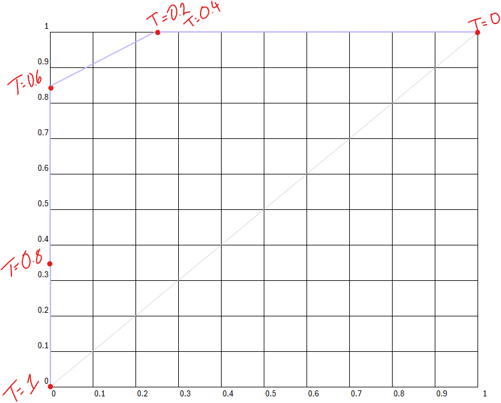

**Matriz 1 - Umbral = 0** --> $T(0) = [1 , 1]$

**Matriz 2 - Umbral = 0.2** --> $T(0.2) = [0.25 , 1]$

**Matriz 3 - Umbral = 0.4** --> $T(0.4) = [0.25 , 1]$

**Matriz 4 - Umbral = 0.6** --> $T(0.6) = [0 , 0.833]$

**Matriz 5 - Umbral = 0.8** --> $T(0.8) = [0 , 0.333]$

**Matriz 6 - Umbral = 1** --> $T(1) = [0 , 0]$

## Parte 2

- b) Verifique el resultado anterior usando el código visto en clase, denominado PROGRAMA1.

↑ Volver al Menú

```python
def programa1(clase, score, labels, umbrales):
  # Graficamos la curva ROC
  fp_r, tp_r, umbral = roc_curve(clase, score, pos_label = "p")
  fig, ax = plt.subplots()
  no_print = ax.plot([0, 1], [0, 1], color = "black", linestyle = 'dashed')
  no_print = ax.plot(fp_r, tp_r)
  no_print = ax.set_xlabel("Tasa de Falsos Positivos")
  no_print = ax.set_ylabel("Tasa de Verdaderos Positivos")
  no_print = ax.set_title("Curva ROC")

  # Graficamos puntos con el siguiente algoritmo
  i = 1  # Contador

  for u in umbrales:
    Prediccion = np.where(score >= u, labels[0], labels[1])
    MC = confusion_matrix(clase, Prediccion)

    FP_r = round(MC[0, 1] / sum(MC[0, ]), 2)
    TP_r = round(MC[1, 1] / sum(MC[1, ]), 2)

    no_print = ax.plot(FP_r, TP_r, "o", color = "red")
    no_print = ax.annotate("T = " + str(round(u, 2)), (FP_r, TP_r + 0.02))

    # Imprimimos resultado
    print("================="*2)
    print("           Matriz ", i)
    print("================="*2)
    print("Probabilidad de Corte = T = ", round(u, 2), "\n")
    print("MC =")
    print(MC, "\n")
    print("Tasa FP = ", round(FP_r, 2))
    print("Tasa TP = ", round(TP_r, 2), '\n')
    i = i + 1
```

```
==================================
           Matriz  1
==================================
Probabilidad de Corte = T =  0.0

MC =
[[0 4]
 [0 6]]

Tasa FP =  1.0
Tasa TP =  1.0

==================================
           Matriz  2
==================================
Probabilidad de Corte = T =  0.2

MC =
[[3 1]
 [0 6]]

Tasa FP =  0.25
Tasa TP =  1.0

==================================
           Matriz  3
==================================
Probabilidad de Corte = T =  0.4

MC =
[[3 1]
 [0 6]]

Tasa FP =  0.25
Tasa TP =  1.0

==================================
           Matriz  4
==================================
Probabilidad de Corte = T =  0.6

MC =
[[4 0]
 [1 5]]

Tasa FP =  0.0
Tasa TP =  0.83

==================================
           Matriz  5
==================================
Probabilidad de Corte = T =  0.8

MC =
[[4 0]
 [4 2]]

Tasa FP =  0.0
Tasa TP =  0.33
```

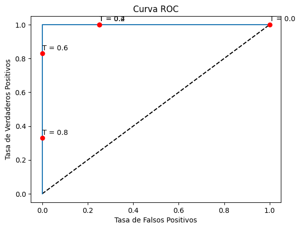

```python
clase = np.array([ 'p', 'n', 'n', 'p', 'n', 'p', 'p', 'p', 'n', 'p'])
score = np.array([0.81, 0.16, 0.40, 0.91, 0.16, 0.66, 0.7, 0.58, 0.01, 0.78])
programa1(clase, score, ["p", "n"], np.arange(0, 1, 0.2))
```

```python
area1 = roc_auc_score(clase, score)
print("Area: ", area1)
```

```
Area:  1.0
```